# Fitting Bayesian time series models

09 Feb 2021

## Overview of today’s material

- Quick overview of Stan
- Manipulating and plotting Stan output
- Examples of time series models

## Review of models we’ve used so far

### Models

- Regression
- ARMA models
- State Space Models
- Dynamic Factor Analysis
- Dynamic Linear Models
- MARSS models (multivariate time series models)

## Why Bayesian?

- Complex hierarchical models
  - Non-linear models
  - Hierarchical or shared parameters
  - Non-normal data
- Inference: what’s the probability that the data are less than some threshold?
- No bootstrapping!
  - We get credible intervals for parameters and states simultaneously

## Using STAN

### What is Stan?

- Powerful, cross-platform and cross-language (R, Julia, Matlab, etc) that allows users to write custom code that can be called directly from R
- Estimation can be fully or approximate Bayesian inference, or maximum likelihood optimization (BFGS)
- Useful links:
  - [Stan homepage](https://mc-stan.org/)
  - [Stan manual](https://mc-stan.org/users/documentation/)
  - [rstan](https://cran.r-project.org/web/packages/rstan/index.html)

## Options for using Stan in this class

- Write your own code (based on examples in the manual, etc)
- Use an existing package
- Use our bundled code to get started with simple models (we’ll start here)

## Existing packages: rstanarm and bmrs

- Both packages very flexible, and allow same syntax as basic lm/glm or lmer models, e.g.

```r
rstan::stan_lm
rstan::stan_glm
rstan::stan_glmer
```

- Vignettes [brms](http://paul-buerkner.github.io/brms/) [rstanarm](http://mc-stan.org/rstanarm/articles/rstanarm.html)

## Potential limitations

`brms` includes autocorrelated errors, non-normal data, non-linear smooths, etc.

- But doesn’t allow for AR processes on parameters / latent variables
- Also doesn’t include multivariate data

## Advantages

`brms` offers notation that should be very familiar to run many classes of models,

```r
brms::brm(y ~ x * z + (1|group), data=d)
brms::brm(y01 ~ x * z + (1|group), data=d, family = binomial("logit"))
brms::brm(bf(y ~ s(x)), data=d)
```

## To install code for this class

- We’ll need to install these packages to run Stan,

```r
install.packages("rstan", repos = "https://cloud.r-project.org")
install.packages("devtools", repos = "https://cloud.r-project.org")
```

- And then we can install our custom package for the class with bundled Stan time series models

```r
devtools::install_github(repo="nwfsc-timeseries/atsar")
install.packages("atsar")
```

## Working with Stan output

- We’ll start with a simple example, using a classic dataset of flow on the Nile River

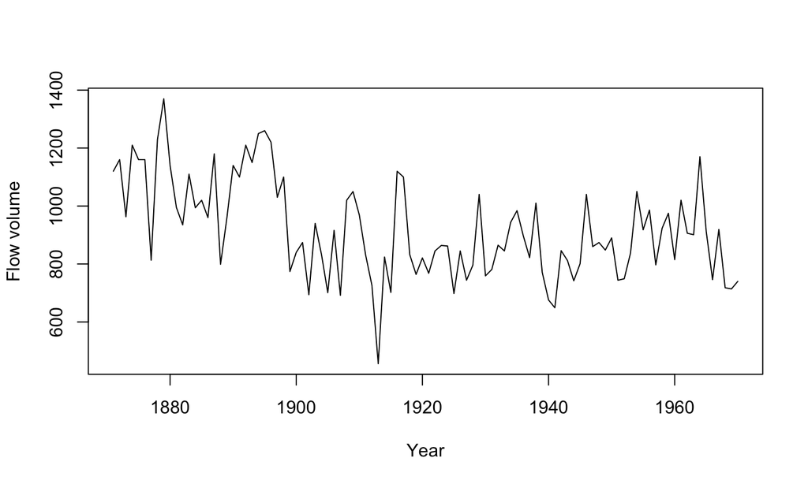

## Working with Stan output

Fitting a regression model to this data doesn’t make a lot of sense, but it will introduce us to the basic functionality of our wrapper functions. We’ll start with a function named `fit_stan`

```r
library(atsar)
lm_intercept = fit_stan(y = as.numeric(Nile),
                        x = rep(1, length(Nile)),
                        model_name = "regression")
```

## Working with Stan output

The output of the fitted model can be examined a number of ways. Starting with the simple summaries,

```r
lm_intercept
```

This model ran 3 MCMC chains (the default) with warmups of 500, followed by 500 more iterations. These latter were stored (so 1500 parameter samples total)

## Working with Stan output

But we’re probably more interested in the values for individual parameters. We can pull these out in a few different ways, and plot them with either base graphics or ggplot. As a first option for getting values we can manipulate, we can use the `extract` function,

```r
pars = rstan::extract(lm_intercept)
```

## Plotting with Stan output

Then we can do all kinds of things with this output, like making a histogram

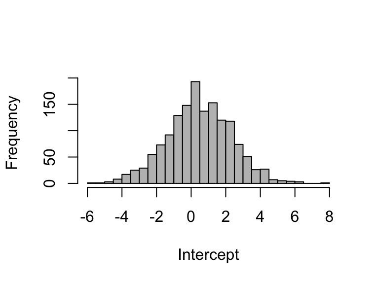

```r
hist(pars$beta, 40, col="grey", xlab="Intercept", main="")
```

or calculate summary statistics

```r
quantile(pars$beta, c(0.025,0.5,0.975))
```

## Plotting with Stan output

The object `lm_intercept` is a `stanfit` object, which means there’s a lot of other plotting functionality from the rstan package we can use

- First, let’s make some traceplots

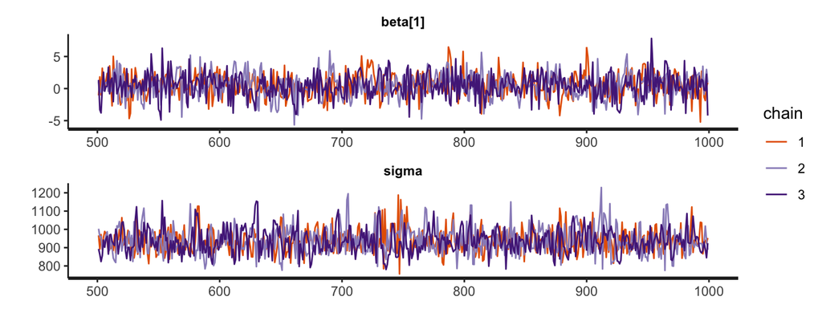

```r
rstan::traceplot(lm_intercept,
                 pars = c("beta[1]","sigma"), nrow=2, ncol=1)
```

## Plotting with Stan output

- Second, we can examine the correlation between parameters with a pairs plot,

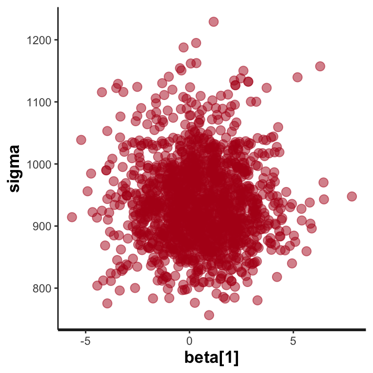

```r
rstan::stan_scat(lm_intercept, pars = c("beta[1]","sigma"))
```

## Plotting with Stan output

- Third, maybe we want to make some density plots or histograms

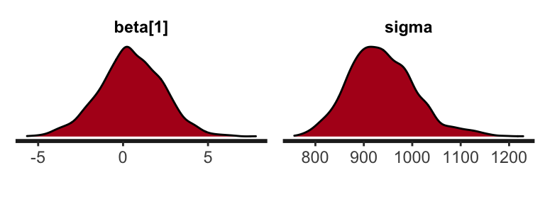

```r
rstan::stan_dens(lm_intercept, pars = c("beta[1]","sigma"))
```

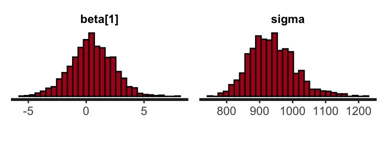

```r
rstan::stan_hist(lm_intercept, pars = c("beta[1]","sigma"))
```

## Plotting with Stan output

- Fourth, we can look at implementing some of the plots included in [bayesplot](http://mc-stan.org/bayesplot/)

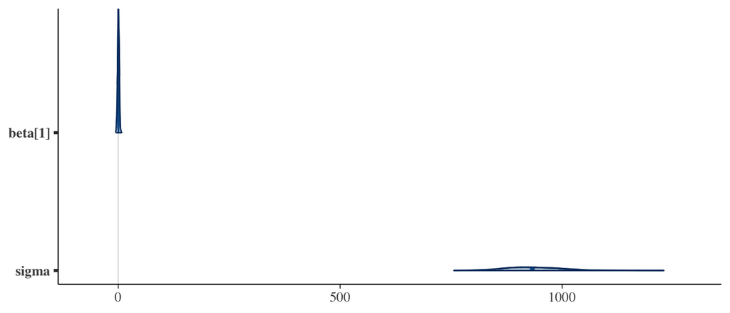

```r
library(bayesplot)
mcmc_areas(as.matrix(lm_intercept),
           pars = c("beta[1]","sigma"),
           prob = 0.8)
```

## Plotting with Stan output

- Another way to show the same uncertainties is with dotplots and credible intervals,

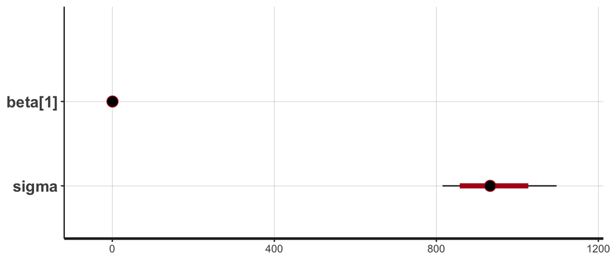

```r
rstan::stan_plot(lm_intercept, pars=c("beta[1]","sigma"))
```

## Plotting with Stan output

- We can also look at the autocorrelation of each parameter, which is another useful diagnostic for convergence (we want very low levels of autocorrelation)

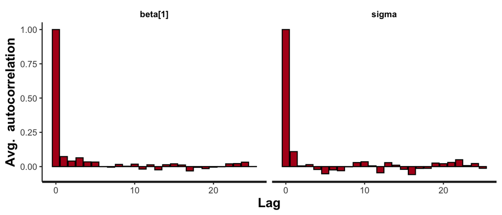

```r
rstan::stan_ac(lm_intercept, pars=c("beta[1]","sigma"))
```

## Plotting with Stan output

These plots only the tip of the iceberg for plotting. For more great examples of the kinds of plots avaialable, see these vignettes:

- [Examples on Stan](https://mc-stan.org/users/interfaces/bayesplot)
- [Jonah Gabry’s introduction to bayesplot](https://cran.r-project.org/web/packages/bayesplot/vignettes/plotting-mcmc-draws.html)
- [Matthew Kay’s introduction to bayesplot and tidybayes](https://cran.r-project.org/web/packages/tidybayes/vignettes/tidybayes.html)

## Tidy summaries from Stan output

Using the `broom.mixed` package, we can also extract some tidy summaries of the output

```r
coef = broom.mixed::tidy(lm_intercept)
head(coef)
```

```
## # A tibble: 6 x 3
##   term    estimate std.error
##   <chr>      <dbl>     <dbl>
## 1 beta[1]    0.418      1.86
## 2 sigma    933.        68.9
## 3 pred[1]    0.418      1.86
## 4 pred[2]    0.418      1.86
## 5 pred[3]    0.418      1.86
## 6 pred[4]    0.418      1.86
```

## Tidy summaries from Stan output

These tidy summaries can then be fed into ggplot for example

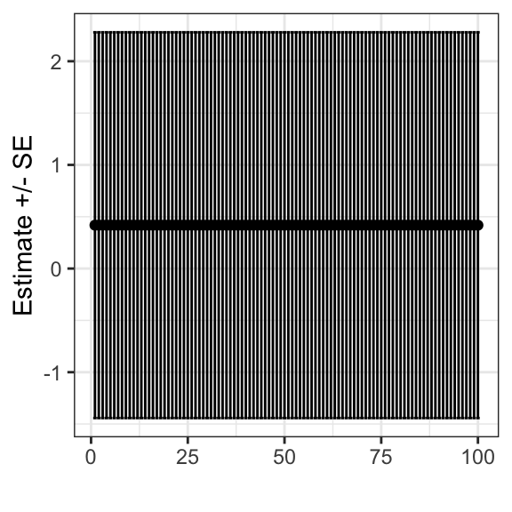

```r
coef = broom.mixed::tidy(lm_intercept)
ggplot(coef[grep("pred",coef$term),], aes(x = 1:100,y=estimate)) +
  geom_point() + ylab("Estimate +/- SE")+ xlab("")+
  geom_errorbar(aes(ymin=estimate-std.error, ymax=estimate+std.error)) +
  theme_bw()
```

## Preserving chain order

For models with multiple chains, we might want to preserve the chain ID to look at individual chain diagnostics. Remember that

- Each chain is independent
- `extract` defaults to merging samples from all chains together, e.g.

```r
extract(object, pars, permuted = TRUE)
```

- But summaries can be generated for each combination of parameters-chains by setting

```r
extract(object, pars, permuted = FALSE)
```

## More time series models: application to NEON EFI Aquatics challenge

Temperature and oxygen data available from Barco Lake in Florida,

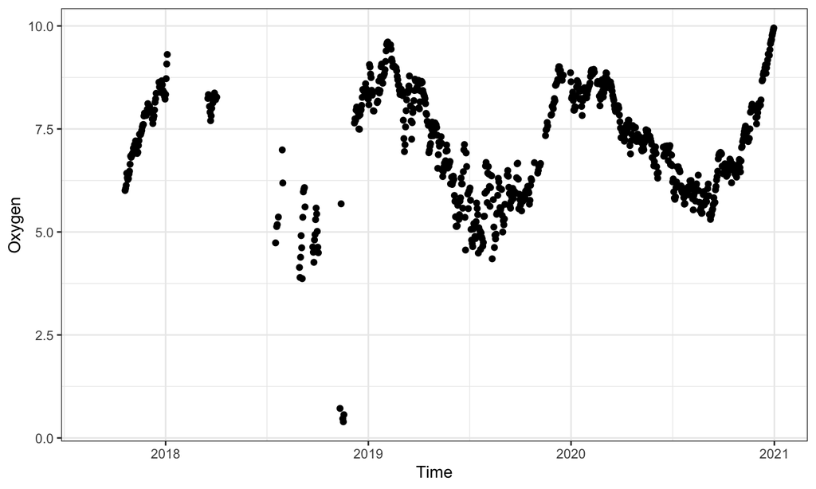

## More time series models: random walk

This model should be familiar,

\[E\left[ { Y }_{ t } \right] =E\left[ { Y }_{ t-1 } \right] +{ e }_{ t-1 }\]

- We’ll fit model to temperature data
- Note that the use of the argument `model_name` and `est_drift`. By not estimating drift, we asssume the process is stationary with respect to the mean

```r
data(airquality)
Temp = airquality$Temp # air temperature
rw = fit_stan(y = Temp, est_drift = FALSE, model_name = "rw")
```

## More time series models: random walk

Did the model converge?

- One quick check is to look at the value of R-hat for each parameter (generally should be small, < 1.05 or smaller)

```r
rw_summary <- summary(rw, pars = c("sigma"),
                      probs = c(0.1, 0.9))$summary
print(rw_summary)
```

```
##           mean    se_mean        sd      10%      90%    n_eff     Rhat
## sigma 5.752748 0.01512101 0.3454789 5.316305 6.216105 522.0133 1.000939
```

## More time series models: univariate state space models

State equation: \[{ x }_{ t }={ \phi x }_{ t-1 }+{ \varepsilon }_{ t-1 }\] where \({ \varepsilon }_{ t-1 } \sim Normal(0, q)\)

Observation equation: \[{ Y }_{ t } \sim Normal(x_{t}, r)\]

- Let’s compare models with and without the AR parameter \(\phi\) in the process model

## More time series models: univariate state space models

We can first run the model with \(\phi\),

```r
ss_ar = fit_stan(y = Temp, est_drift=FALSE, model_name = "ss_ar")
```

then without,

```r
ss_rw = fit_stan(y = Temp, est_drift=FALSE, model_name = "ss_rw")
```

## More time series models: univariate state space models

Estimates from the AR(1) state space model

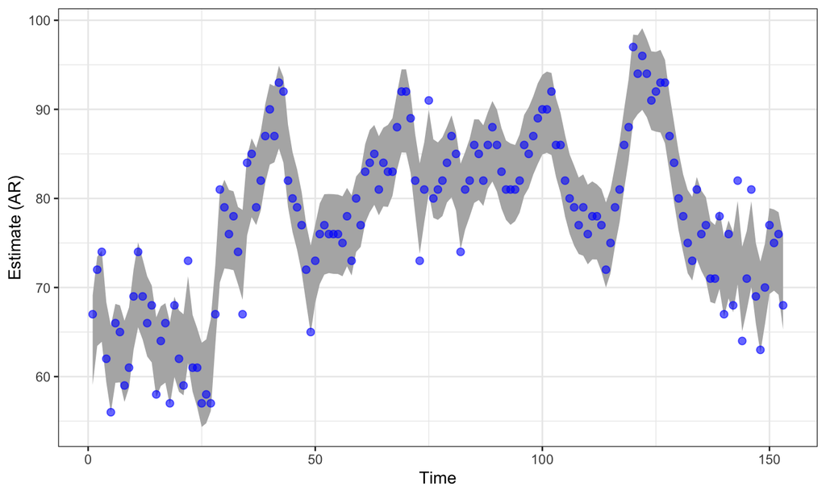

## More time series models: univariate state space models

Estimates from the RW state space model

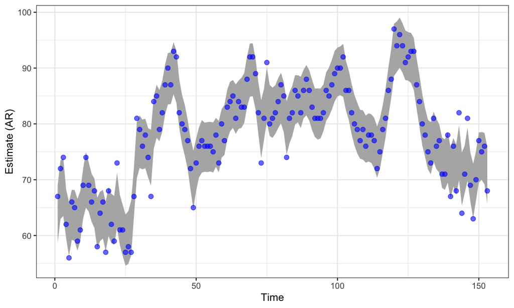

## More time series models: univariate state space models

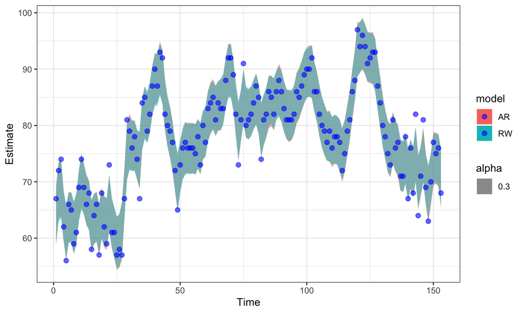

## More time series models: univariate state space models

We might be also interested in looking at posterior estimates for these models.

- What is the posterior distribution of \(\phi\)?

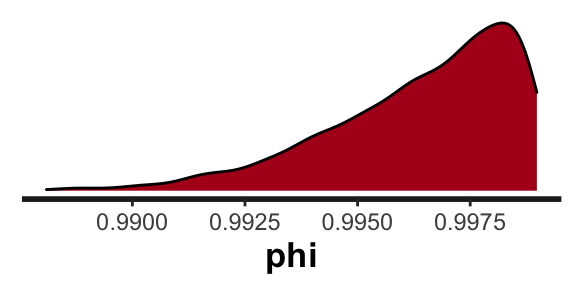

```r
rstan::stan_dens(ss_ar, c("phi"))
```

## More time series models: univariate state space models

We might also be interested in derived quantities.

- For example, what’s the probability of temperature exceeding 90 degrees?

```r
pars = extract(ss_ar)
p = length(which(pars$pred > 90)) / length(pars$pred)
print(round(p,3))
```

```
## [1] 0.077
```

## Dynamic Factor Analysis (DFA)

As an example of Bayesian DFA, we’ll load the WA plankton dataset. There’s 3 versions of the data, and we’ll use the one that’s been transformed. As a reminder,

```
+ 0s replaced with NAs
+ data have been z-scored
+ we only use data from 1980-1989 for simplicity
```

```r
dat = lakeWAplanktonTrans
plankdat = dat[dat[,"Year"]>=1980 & dat[,"Year"]<1990,]
phytoplankton = c("Cryptomonas", "Diatoms", "Greens",
                   "Unicells", "Other.algae")
dat.spp.1980 = plankdat[,phytoplankton]
```

## Dynamic Factor Analysis (DFA)

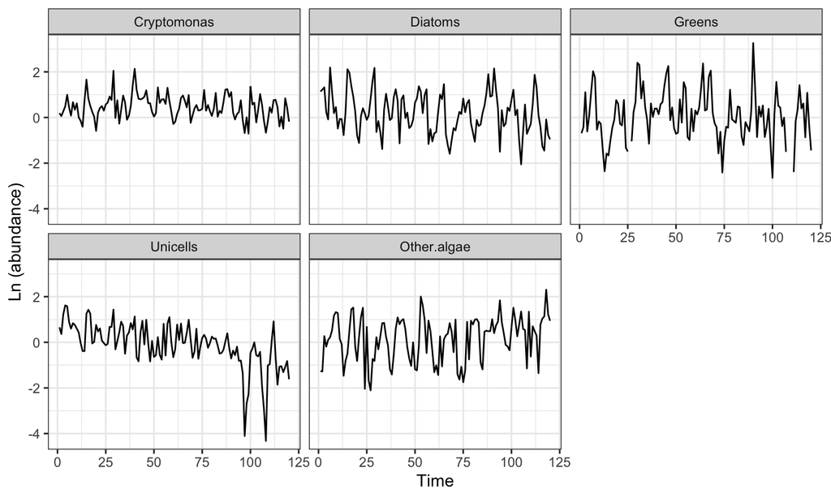

## Running the model

For starters, we’ll try a 3-trend model,

```r
mod_3 = fit_dfa(y = t(dat.spp.1980), num_trends=3)
```

## Trends need to be rotated (like MARSS)

Why? Identifiability

- Try re-ordering time series, and running DFA on each new dataset
- Results will be sensitive to time series order, BUT not after rotation
- Like MARSS we’ll use varimax rotation

Use function we’ve written, rotate_trends

## Attributes of rotated object

`Z_rot`, rotated Z matrix for each MCMC draw  
`trends`, rotated trends for each MCMC draw  
`Z_rot_mean`, mean Z across draws  
`trends_mean`, mean trends across draws  
`trends_lower`, lower 2.5% on trends  
`trends_upper`, upper 97.5% on trends

## Other variance structures

By default, the structure is `diagonal and equal`

```r
mod_3 = fit_dfa(y = t(dat.spp.1980), num_trends=3, varIndx = rep(1,5))
```

## Uncertainty intervals on states

We often just present the trend estimates for DFA – but not uncertainty

Let’s look at effect of missing data on DFA for the harbor seal dataset

```r
data("harborSealWA")
```

## Model

Assume single trend for the population

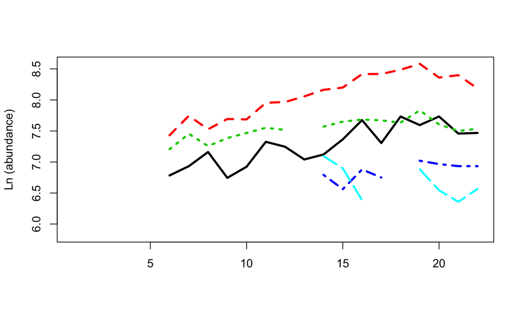